# Computational Homework #4

#### (d) Plot the residuals (y) against the fitted values (x). Does the variability in the residuals look constant as the fitted values increase? Interpret why that might be important. Also, produce a normal QQ-plot of the residuals. If the points of the QQ-plot roughly follow the line $y = x$, then we don’t have evidence against normality of the residuals. How does the QQ-plot look for these residuals?

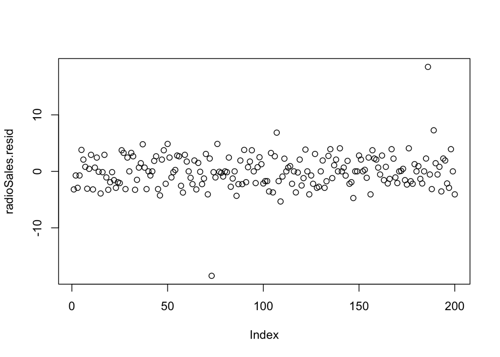

```r
radioSales.resid = resid(radioSales)
plot(radioSales.resid)
```

```r
print("Yes, with the exception of 2 samples, this a good indication that the difference between the observed and fitted data across the samples is very similar or constant.")
```

```
## [1] "Yes, with the exception of 2 samples, this a good indication that the difference between the observed and fitted data across the samples is very similar or constant."
```

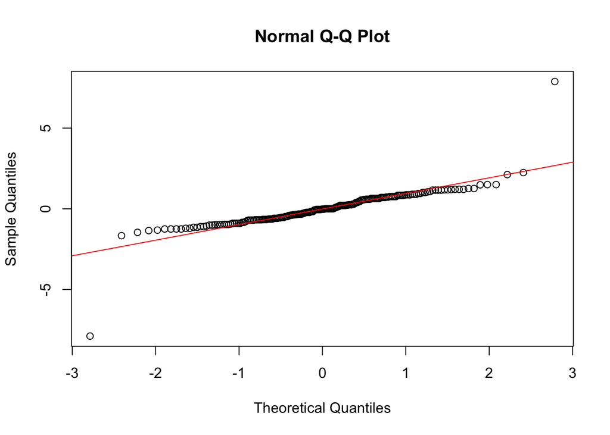

```r
radioSales.stdres = rstandard(radioSales)
qqnorm(radioSales.stdres)
qqline(radioSales.stdres, col = "red")
```

```r
print("The points of the QQ-plot roughly follow the line (y = x), thus we don't have evidence against normality of the residuals.")
```

```
## [1] "The points of the QQ-plot roughly follow the line (y = x), thus we don't have evidence against normality of the residuals."
```

#### (e) We learned that, often, the goal of regression is to make predictions on new data. Let’s see how well the model does at predicting values that we left out of the training set.

#### We can get a sense of how well the model does at predicting by computing the prediction mean squared error (MSE):

$$MSE = \frac{1}{n}\sum^n_{i=1}\bigg(y_i - \widehat{y}_i \bigg)^2.$$

#### Compute the MSE for the data in the training set, and for data in the testing set. Which one is lower? Explain why you think it’s lower.

```r
radioSlaes.train = lm(radio ~ sales, data = train)
yHat.train <- predict(radioSlaes.train)
#train.MSE <- mean((train$Radio - yHat.train)^2)
print("Can not figure out how to make this work?")
```

```
## [1] "Can not figure out how to make this work?"
```

### Problem #3

Now let’s perform multiple linear regression using the dataset from the previous problem.

#### (a) Perform MLR, using your training set, using sales as the response and all other variables as predictors.

```r
#x <- (train$Market + train$TV + train$Radio + train$Newspaper)
#mlr <- lm(x ~ Sales, data = train)
#summary(mlr)
```

#### (c) Plot the residuals (y) against the fitted values (x). Do you notice any curvature in the residual plot? Also, produce a normal QQ-plot of the residuals. Do you have any worries about the normality of the residuals?

```r
print("Could not continue here as I could not get the previous part to work?")
```

```
## [1] "Could not continue here as I could not get the previous part to work?"
```

#### (c) Compute the MSE for the data in the training set, and for data in the testing set. Which one is lower? Explain why you think it’s lower.

```r
print("Could not continue here as I could not get the previous part to work?")
```

```
## [1] "Could not continue here as I could not get the previous part to work?"
```